# Transit of sun through the seasonal nakṣatra cycle in the Vṛddha-Gārgīya Jyotiṣa

## [Indian Journal of History of Science, 56.3(2021)](https://insa.nic.in//writereaddata/UpLoadedFiles/IJHS/1.pdf)

## Fig 1 - Yearly variation of the nakṣatra location error Ey in the seasonal solar zodiac of VGJ.

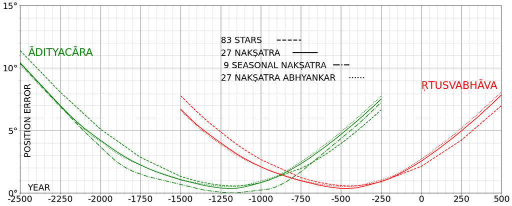

## Fig. 2. Error sensitivity for possible identification of Vedic star śraviṣṭhā as β Aquari and śravaṇa as β Delphini.

- The readjusted 27 proxy stars and the yogatāras of Abhyankar lead to almost the same result of c 1250 BCE for the error minimum.
- Errors for the nine seasonal nakṣatra boundaries remain zero during 1700–1350 BCE.

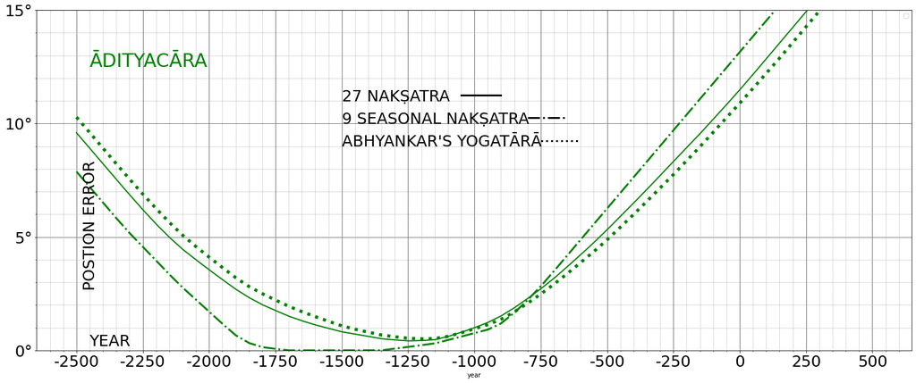

## Fig.3. Twelve month (madhu-tapasya) or (caitra-phālguna) sun’s transit in 500 BCE as per the Ṛtusvabhāva (59th aṅga) of VGJ.

- The points are joined smoothly for better visualization with markings for the seasons and the months.
- It can be verified that all the twelve nakṣatra named in the VGJ text would have been visible sometime in the specified months.

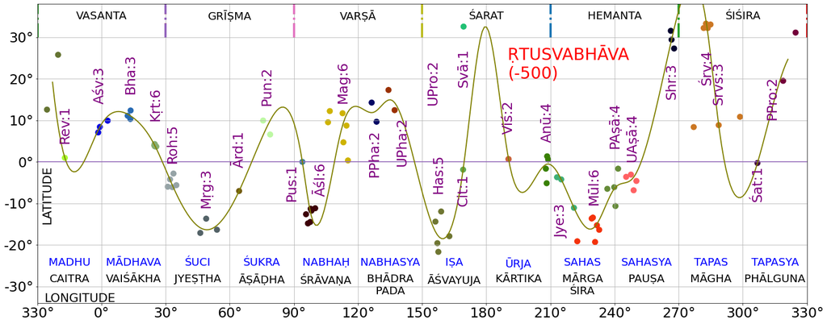

## One Year full moon overlaid on Seasons and Nakṣatras for -1500

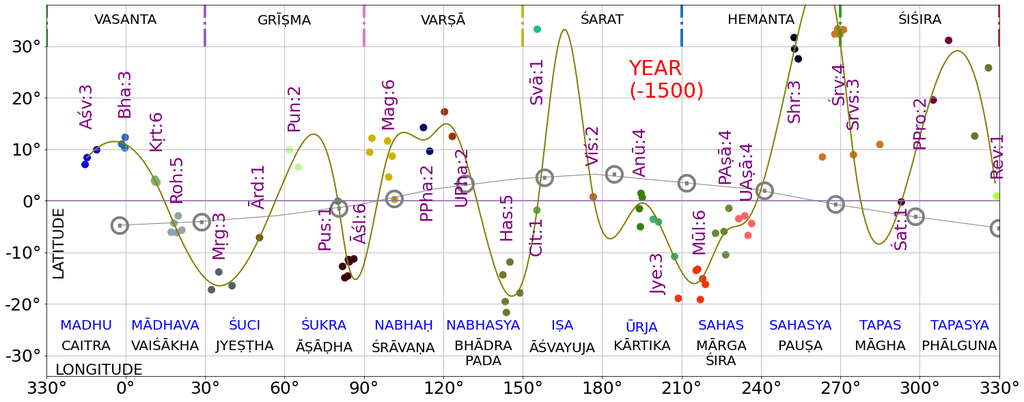

[figure not shown]

## One Year full moon overlaid on Seasons and Nakṣatras for -1500

- Plot of RA and Dec and Full Moon size indicated

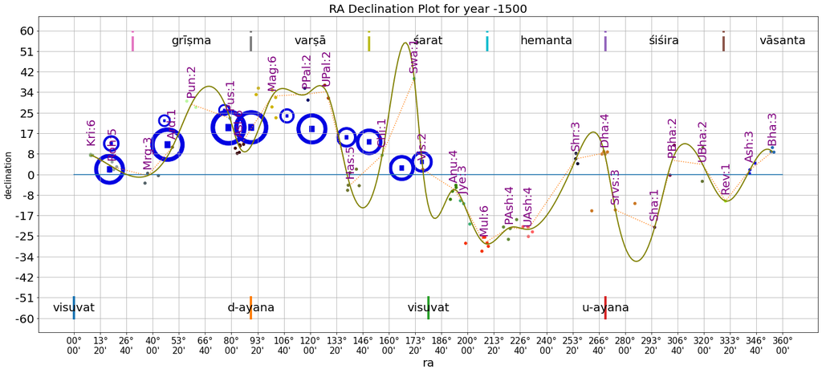

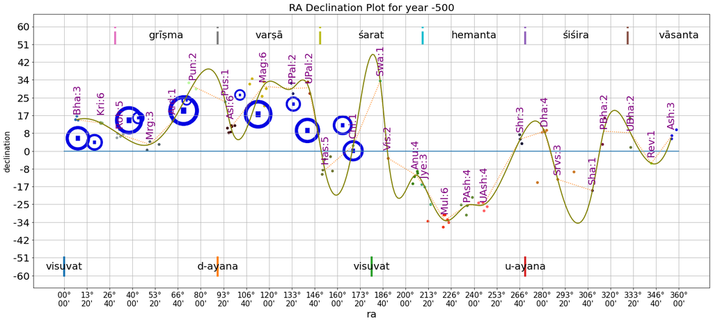

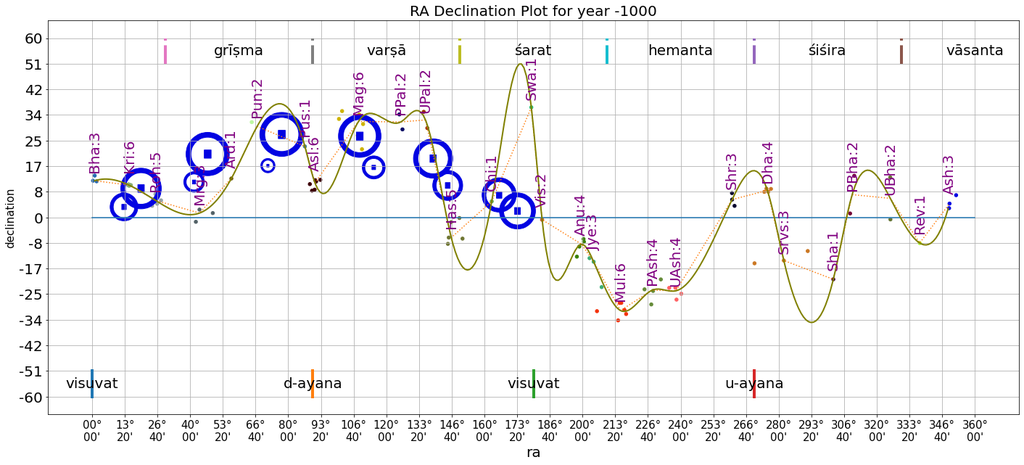

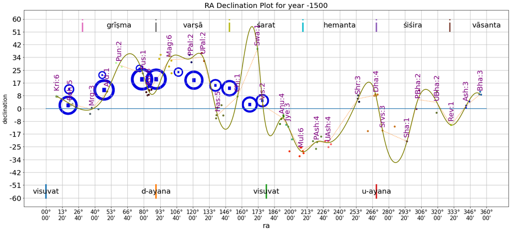

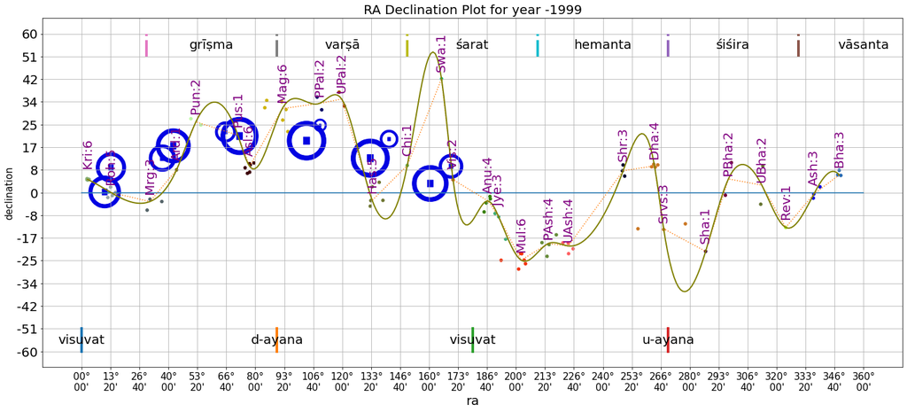

- Plot of RA and Dec ; Black is krishna paksha, Blue is shukla paksha
- Size indicates the phase of the moon

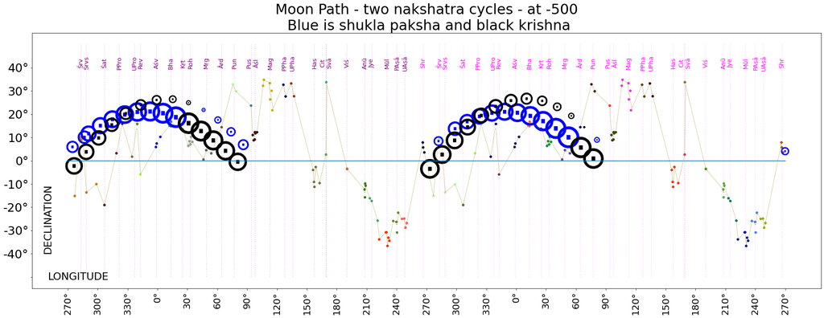

## Plot of Nakṣatra locations in their respective divisions

- Red Band indicates where the nakṣatra bound is highest

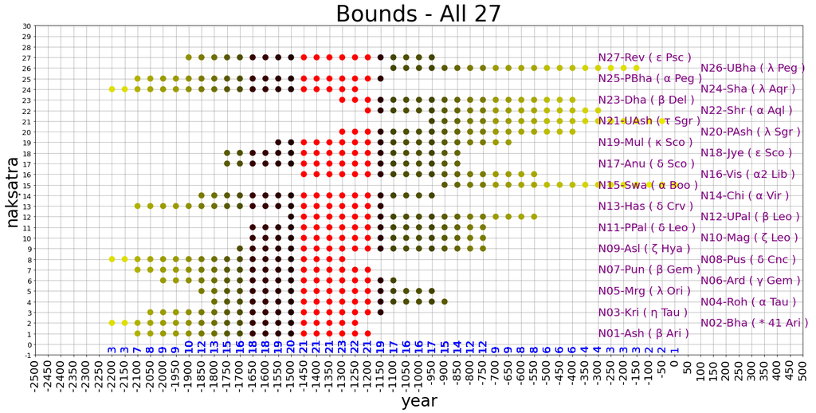

## Seasons per Ādityacāra

```
  श्रविष्ठादीनि चत्वारि पौष्णार्धञ्च दिवाकरः । वर्धयन् सरसस्तिक्तं मासौ तपति शैशिरे ॥
  रोहिण्यन्तानि विचरन् पौष्णार्धाद्याच्च भानुमान् । मासौ तपति वासन्तौ कषायं वर्धयन् रसम् ॥
  सार्पार्धान्तानि विचरन् सौम्याद्यानि तु भानुमान् । ग्रैष्मिकौ तपते मासौ कटुकं वर्धयन् रसम् ॥
  सावित्रान्तानि विचरन् सार्पार्धाद्यानि भास्करः । वार्षिकौ तपते मासौ रसमम्लं विवर्धयन् ॥
  चित्रादीन्यथ चत्वारि ज्येष्ठार्धञ्च दिवाकरः । शारदौ लवणाख्यं च तपत्याप्याययन् रसम् ॥
  ज्येष्ठार्धादीनि चत्वारि वैष्णवान्तानि भास्करः । हेमन्ते तपते मासौ मधुरं वर्धयन् रसम् ॥
  (Ādityacāra; v. 47, 48, 52, 53, 54, 55)
```

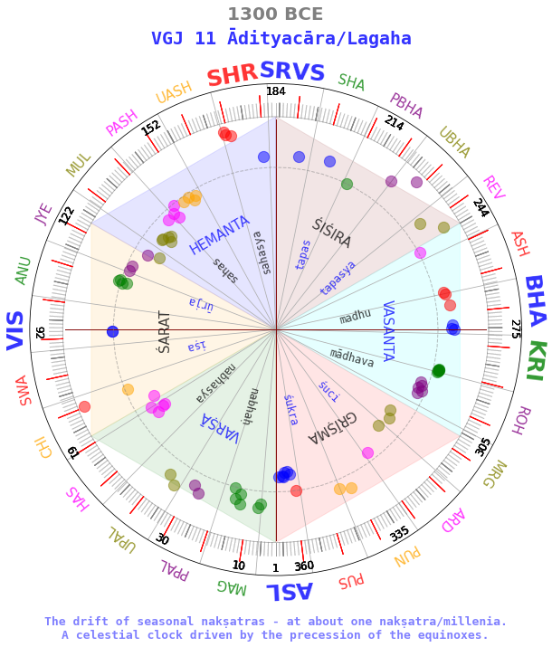

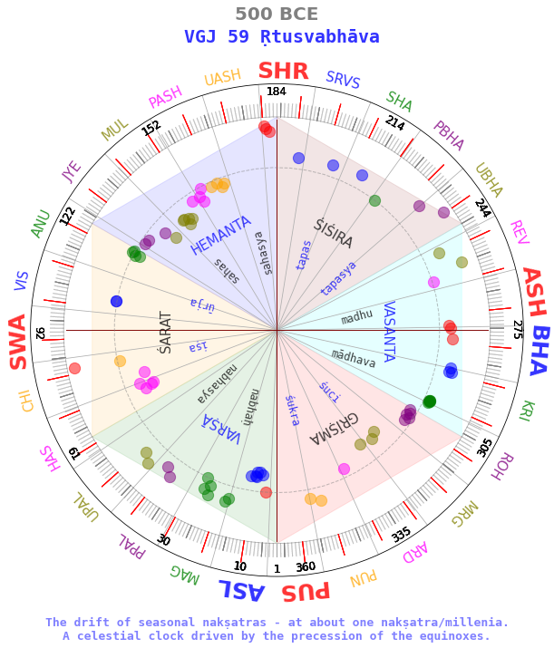

## Table 1. Nakṣatra Constituents and proxy stars of the 11th Section of VGJ.

[output not shown]

## Path of Mars without and with Vakra

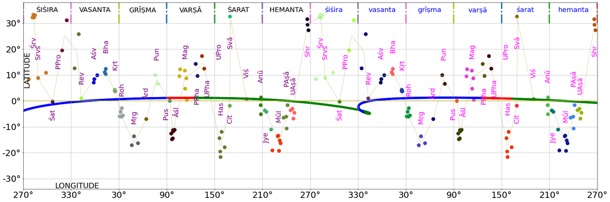

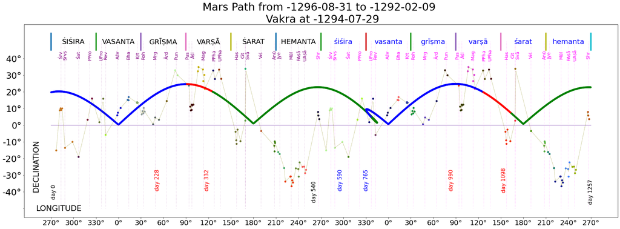

## Plot of Sun-Gruha angular gap annotated with visibility and rise/set events

```
Writing to file ../datasets/nakshatras/mercury-events.tsv
Writing to file ../datasets/nakshatras/venus-events.tsv
Writing to file ../datasets/nakshatras/mars-events.tsv
```

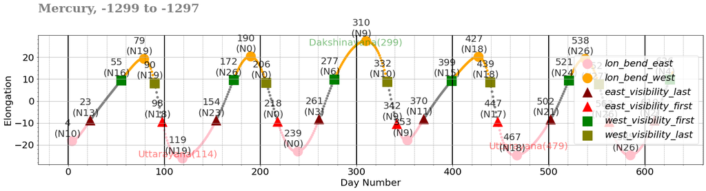

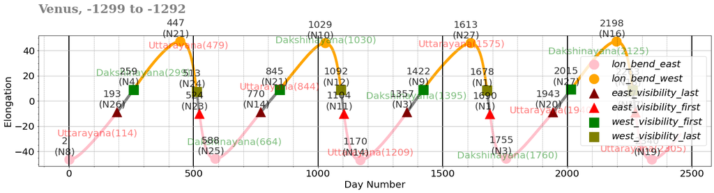

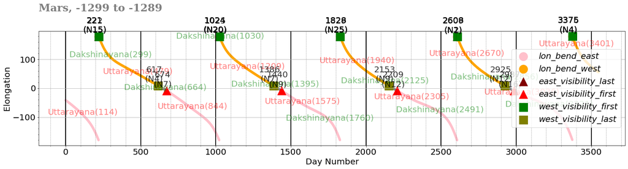

## Venus morning/evening first/last visibility

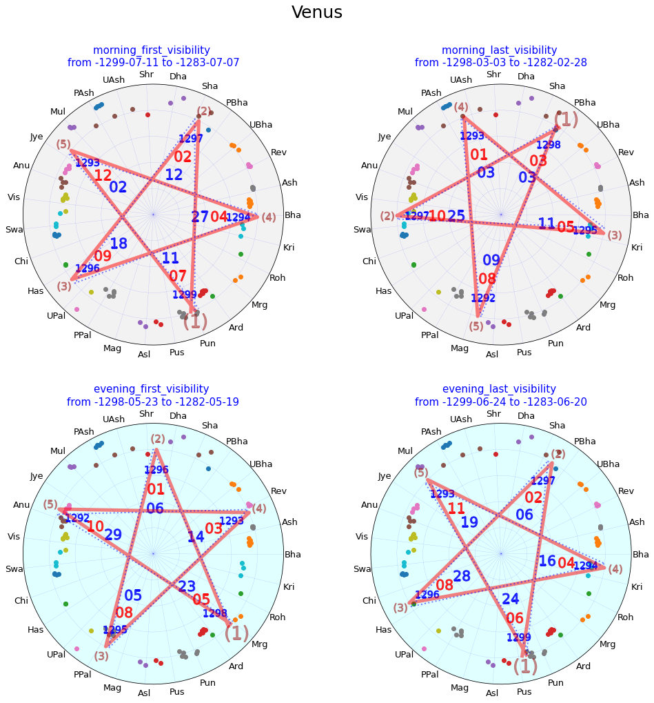

[output not shown]